# Using tree based methods to detect customer churn and customer calue for an Iranian call centre

### Support Vector Machine for Regression

In the context of predicting customer value, the Support Vector Regression (SVR) models were evaluated for their predictive performance. The RBF SVR achieved the best results with a Mean Squared Error (MSE) of 0.0063 and Mean Absolute Error (MAE) of 0.0601, indicating highly accurate predictions with minimal error. In contrast, the Linear SVR and Least Squares Estimation (LSE) models showed higher error values, suggesting they were less effective in capturing the underlying patterns in customer value data. These results highlight that the non-linear RBF SVR model is best suited for modeling complex relationships in customer behavior, making it the most reliable approach for accurately predicting customer value in this scenario.

```r
# Load dataset
#library(e1071)
#library(MASS)
#####
#str(callcenter.data)
# Split data into features (X) and target (y)
X <- df_numeric[, -8]  # All columns except the target variable
y <- df_numeric[, 8]   # Target variable (median house value)
#####
# Split data into training and testing sets
set.seed(123)
train.index <- sample(1:nrow(df_numeric), 0.8 * nrow(df_numeric))
X.train <- X[train.index, ]
y.train <- y[train.index]
X.test <- X[-train.index, ]
y.test <- y[-train.index]
#####
callcenter.train <- df_numeric[train.index, ]
callcenter.test <- df_numeric[-train.index, ]
#####
## Set up custom cross-validation control
tune.control <- tune.control(
  cross = 5,  # Use 5-fold cross-validation, the default is 10-fold cross-validation
  nrepeat = 1 # Number of repetitions (for repeated cross-validation)
)
#####
# Perform grid search for hyperparameter tuning: RBF kernel is used
tune.RBF <- tune(svm, train.x = X.train, train.y = y.train,
                    ranges = list(epsilon = seq(0.1, 0.5, 0.1),
                                  cost = c(1, 10, 100),
                                  gamma = c(0.01, 0.1, 1)), # Hyperpar in RBF
                    tunecontrol = tune.control(sampling = "cross",
                                               cross = 5) # 5-fold cross-validation
                    )
####
# Display the best parameters
#print(tune.result$best.parameters)
#####
# Train the final model using the best parameters
final.RBF<- svm(X.train, y.train,
                   type = "eps-regression",  # Use "nu-regression" for nu-SVR
                   kernel = "radial",
                   epsilon = tune.RBF$best.parameters$epsilon,
                   cost = tune.RBF$best.parameters$cost,
                   gamma = tune.RBF$best.parameters$gamma)
#####
# Make predictions on the test set
pred.RBF <- predict(final.RBF, X.test)

# Evaluate performance
mse.RBF <- mean((y.test - pred.RBF)^2)    # mean square error
mae.RBF <- mean(abs(y.test - pred.RBF))   # mean absolute error

#### linear kernel

# Perform grid search for hyperparameter tuning: RBF kernel is used
tune.lin <- tune(svm, train.x = X.train, train.y = y.train,
                    ranges = list(epsilon = seq(0.1, 0.5, 0.1),
                                  cost = c(1, 10, 100)),
                    tunecontrol = tune.control(sampling = "cross",
                                               cross = 5) # 5-fold cross-validation
                    )
####
# Display the best parameters
#print(tune.result$best.parameters)
#####
# Train the final model using the best parameters
final.lin<- svm(X.train, y.train,
                   type = "eps-regression",  # Use "nu-regression" for nu-SVR
                   kernel = "linear",
                   epsilon = tune.lin$best.parameters$epsilon,
                   cost = tune.lin$best.parameters$cost)
#####
# Make predictions on the test set
pred.lin <- predict(final.lin, X.test)

# Evaluate performance
mse.lin <- mean((y.test - pred.lin)^2)    # mean square error
mae.lin <- mean(abs(y.test - pred.lin))   # mean absolute error
```

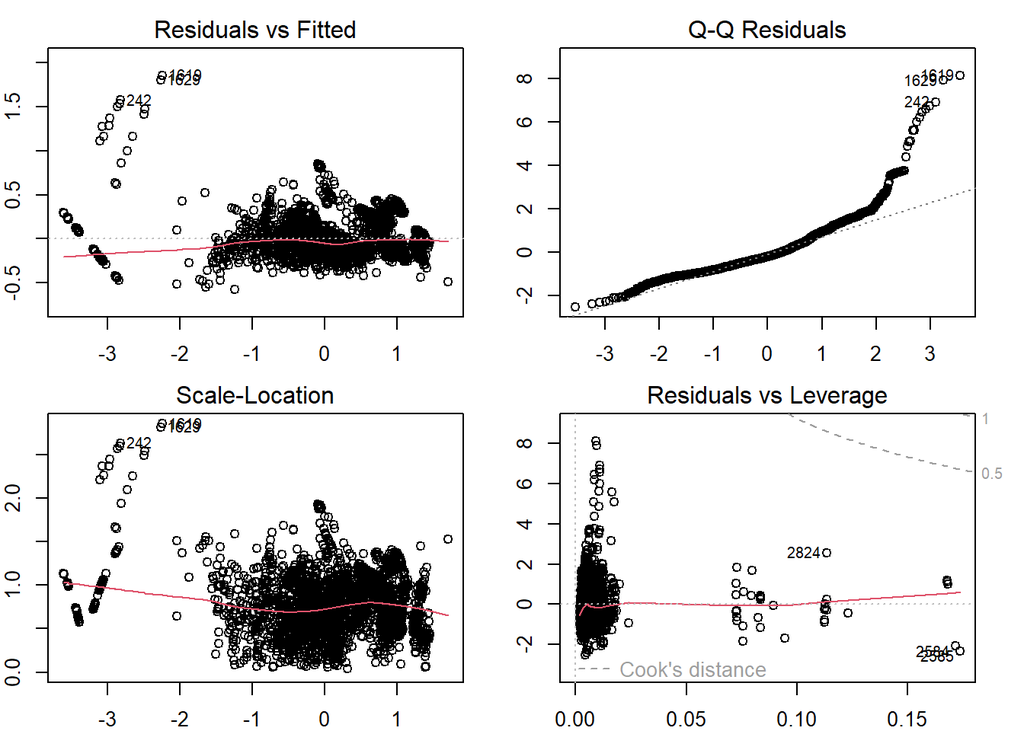

```r
## ordinary LSE regression model with stepwise variable selection
lse.fit <- lm(Customer_Value_stan~.,data=callcenter.train)
AIC.fit <- stepAIC(lse.fit,direction="both", trace = FALSE)
pred.lse <- predict(AIC.fit, X.test)
mse.lse <- mean((y.test - pred.lse)^2)    # mean square error
mae.lse <- mean(abs(y.test - pred.lse))   # mean absolute error
###
par(mfrow=c(2,2), mar=c(2,2,2,2))
plot(AIC.fit)
```

```r
###
Performance <- data.frame(RBF.SVR=c(mse.RBF, mae.RBF),
                          Linear.SVR = c(mse.lin, mae.lin),
                          LSE.Reg =c(mse.lse, mae.lse))
row.names(Performance) <- c("MSE", "MAE")
##
pander(Performance)
```

|  | RBF.SVR | Linear.SVR | LSE.Reg |
| --- | --- | --- | --- |
| **MSE** | 0.006255 | 0.06253 | 0.05934 |
| **MAE** | 0.06014 | 0.1722 | 0.1795 |